# Movilidad Intergeneracional de Ingresos: Simulación

Fecha de publicación

20 de marzo de 2026

# La Elasticidad Intergeneracional del Ingreso (IGE)

La Elasticidad Intergeneracional del Ingreso (IGE) es la medida más utilizada para cuantificar la movilidad económica entre generaciones. Fue desarrollada y popularizada en la literatura académica por autores como Gary Solon (1992) y David Zimmerman (1992).

El modelo estándar de la IGE se estima mediante la siguiente regresión log-log:

$$\log(y_h^i) = \alpha + \beta \cdot \log(y_p^i) + \varepsilon^i$$

donde:

- $y_h^i$ es el ingreso del hijo (o hija) del hogar $i$ en la adultez
- $y_p^i$ es el ingreso de los padres del hogar $i$, medido típicamente durante la niñez o adolescencia del hijo
- $\alpha$ es una constante que refleja el nivel promedio de ingresos de la generación hije, independientemente de los padres
- $\beta$ es el coeficiente de elasticidad intergeneracional, el parámetro central de interés
- $\varepsilon^i$ es el término de error estocástico, que captura todo lo que afecta el ingreso del hijo más allá del ingreso parental (capital humano, redes sociales, esfuerzo, suerte, etc.)

El coeficiente $\beta$ tiene una interpretación directa y poderosa:

> Un valor de $\beta = 0.7$ significa que si los padres tienen un ingreso 1% por encima del promedio, se espera que sus hijos tengan un ingreso 0.7% por encima del promedio de su propia generación.

Los casos extremos son igualmente informativos:

| Valor de $\beta$ | Interpretación |
| --- | --- |
| $\beta = 0$ | Movilidad perfecta: el ingreso de los padres no predice en absoluto el del hijo. La posición socioeconómica es completamente aleatoria entre generaciones. |
| $\beta = 1$ | Inmovilidad perfecta: el ingreso relativo se transmite íntegramente de padres a hijos. La posición social es completamente hereditaria. |

## El papel de $\varepsilon$

El término de error $\varepsilon \sim \mathcal{N}(0, \sigma^2_\varepsilon)$ representa la dispersión alrededor del ingreso esperado (condicional en el ingreso de los padres). Su desviación estándar $\sigma_\varepsilon$ tiene una interpretación sustantiva:

- $\sigma_\varepsilon$ pequeño implica que el ingreso parental es altamente predictivo: dado el ingreso de los padres, el rango de ingresos posibles para el hijo es estrecho. Esto ocurre en sociedades muy rígidas.
- $\sigma_\varepsilon$ grande implica que hay mucha variación en los ingresos de los hijos con un mismo ingreso parental. Esto puede reflejar tanto mayor movilidad real como mayor incertidumbre económica.

# Simulación: efectos de $\beta$ y $\sigma_\varepsilon$ sobre la movilidad

**Código**

```r
library(tidyverse)

set.seed(42)
n <- 10000

# Generamos ingresos parentales uniformes entre $100 y $12,000
y_p <- runif(n, 100, 12000)

# Parámetros a variar
betas  <- c(0.3, 0.6, 0.9)
sigmas <- c(0.15, 0.85)

beta_labels  <- c("0.3" = "β = 0.3 (Alta movilidad)",
                   "0.6" = "β = 0.6 (Movilidad media)",
                   "0.9" = "β = 0.9 (Baja movilidad)")

sigma_labels <- c("0.15" = "σ_ε = 0.15 (Bajo ruido)",
                   "0.85" = "σ_ε = 0.85 (Alto ruido)")

# Construimos la grilla de simulaciones
sim_data <- expand_grid(beta = betas, sigma = sigmas) %>%
  mutate(data = map2(beta, sigma, function(b, s) {
    e        <- rnorm(n, mean = 0, sd = s)
    log_yh   <- 0 + b * log(y_p) + e
    tibble(
      log_yp  = log(y_p),
      log_yh  = log_yh,
      y_p     = y_p,
      y_h     = exp(log_yh)
    )
  })) %>%
  unnest(data) %>%
  mutate(
    beta_label  = beta_labels[as.character(beta)],
    sigma_label = sigma_labels[as.character(sigma)],
    beta_label  = factor(beta_label,  levels = beta_labels),
    sigma_label = factor(sigma_label, levels = sigma_labels)
  )
```

## Escenario 1: Dispersión baja ($\sigma_\varepsilon = 0.15$) — el ingreso parental domina

Cuando la dispersión del error es pequeña, la posición socioeconófica del hijo queda casi determinada por la de los padres. La nube de puntos es estrecha y la pendiente $\beta$ es el factor dominante.

**Código**

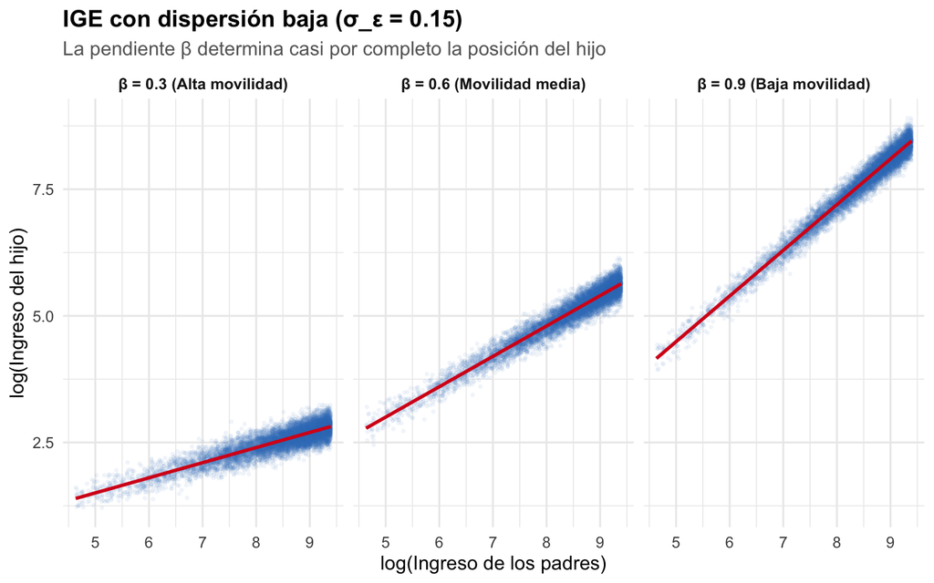

Figura 1: Transmisión intergeneracional con baja dispersión del error. Cada panel muestra un nivel de β distinto.

```r
sim_data %>%
  filter(sigma == 0.15) %>%
  ggplot(aes(x = log_yp, y = log_yh)) +
  geom_point(alpha = 0.05, size = 0.6, color = "#2c7bb6") +
  geom_smooth(method = "lm", se = TRUE, color = "#d7191c", linewidth = 1) +
  facet_wrap(~beta_label, ncol = 3) +
  labs(
    title    = "IGE con dispersión baja (σ_ε = 0.15)",
    subtitle = "La pendiente β determina casi por completo la posición del hijo",
    x        = "log(Ingreso de los padres)",
    y        = "log(Ingreso del hijo)"
  ) +
  theme_minimal(base_size = 12) +
  theme(
    strip.text      = element_text(face = "bold"),
    plot.title      = element_text(face = "bold"),
    plot.subtitle   = element_text(color = "gray40")
  )
```

Interpretación: Con $\sigma_\varepsilon = 0.15$, la nube de puntos es compacta. Cuando $\beta = 0.3$, incluso con poco ruido, un hijo de padres ricos solo tiene una ventaja moderada — la línea sube poco. Con $\beta = 0.9$, en cambio, casi toda la variación en el ingreso del hijo refleja la del padre: la sociedad es una “lotería hereditaria” con muy poco espacio para el talento o el esfuerzo individual.

## Escenario 2: Dispersión alta ($\sigma_\varepsilon = 0.85$) — el azar importa más

Cuando aumentamos la dispersión del error, introducimos mayor incertidumbre. Incluso con un $\beta$ alto, ahora hay más hijos de padres pobres que “escapan” hacia arriba y más hijos de ricos que caen. La nube se ensancha.

**Código**

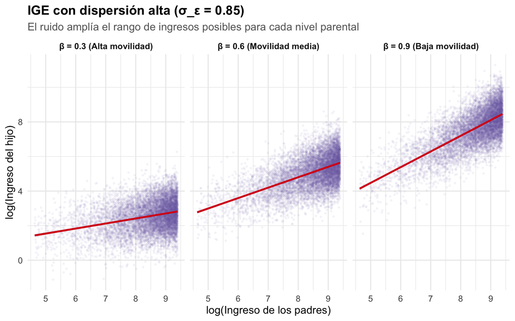

Figura 2: Transmisión intergeneracional con alta dispersión del error.

```r
sim_data %>%
  filter(sigma == 0.85) %>%
  ggplot(aes(x = log_yp, y = log_yh)) +
  geom_point(alpha = 0.05, size = 0.6, color = "#756bb1") +
  geom_smooth(method = "lm", se = TRUE, color = "#d7191c", linewidth = 1) +
  facet_wrap(~beta_label, ncol = 3) +
  labs(
    title    = "IGE con dispersión alta (σ_ε = 0.85)",
    subtitle = "El ruido amplía el rango de ingresos posibles para cada nivel parental",
    x        = "log(Ingreso de los padres)",
    y        = "log(Ingreso del hijo)"
  ) +
  theme_minimal(base_size = 12) +
  theme(
    strip.text      = element_text(face = "bold"),
    plot.title      = element_text(face = "bold"),
    plot.subtitle   = element_text(color = "gray40")
  )
```

Interpretación: Con $\sigma_\varepsilon = 0.85$, hay más “ruido” en la transmisión. Incluso con $\beta = 0.9$, la nube de puntos es considerablemente más dispersa que en el escenario anterior. Esto representa sociedades donde factores como la educación pública de calidad, la suerte, o las redes sociales horizontales pueden cambiar de manera significativa la trayectoria de un individuo más allá de lo que predice el ingreso parental.

## Estimación del modelo por escenario

Para cada combinación de parámetros, estimamos el modelo OLS y recuperamos el $\hat{\beta}$:

**Código**

```r
resultados <- sim_data %>%
  group_by(beta, sigma, beta_label, sigma_label) %>%
  summarise(
    modelo      = list(lm(log_yh ~ log_yp)),
    .groups     = "drop"
  ) %>%
  mutate(
    beta_est    = map_dbl(modelo, ~ coef(.x)[["log_yp"]]),
    beta_se     = map_dbl(modelo, ~ summary(.x)$coefficients["log_yp", "Std. Error"]),
    r_squared   = map_dbl(modelo, ~ summary(.x)$r.squared)
  ) %>%
  select(beta_label, sigma_label, beta_verdadero = beta, beta_est, beta_se, r_squared)

resultados %>%
  mutate(across(where(is.numeric), ~ round(.x, 4))) %>%
  rename(
    "Escenario β"        = beta_label,
    "Escenario σ_ε"      = sigma_label,
    "β verdadero"        = beta_verdadero,
    "β estimado"         = beta_est,
    "Error estándar"     = beta_se,
    "R²"                 = r_squared
  ) %>%
  knitr::kable(align = "lllcccc")
```

Tabla 1: Estimaciones OLS del coeficiente β por escenario de simulación

| Escenario β | Escenario σ_ε | β verdadero | β estimado | Error estándar | R² |
| --- | --- | --- | --- | --- | --- |
| β = 0.3 (Alta movilidad) | σ_ε = 0.15 (Bajo ruido) | 0.3 | 0.2983 | 0.0016 | 0.7658 |
| β = 0.3 (Alta movilidad) | σ_ε = 0.85 (Alto ruido) | 0.3 | 0.2911 | 0.0094 | 0.0869 |
| β = 0.6 (Movilidad media) | σ_ε = 0.15 (Bajo ruido) | 0.6 | 0.5996 | 0.0017 | 0.9289 |
| β = 0.6 (Movilidad media) | σ_ε = 0.85 (Alto ruido) | 0.6 | 0.6024 | 0.0093 | 0.2944 |
| β = 0.9 (Baja movilidad) | σ_ε = 0.15 (Bajo ruido) | 0.9 | 0.9024 | 0.0016 | 0.9687 |
| β = 0.9 (Baja movilidad) | σ_ε = 0.85 (Alto ruido) | 0.9 | 0.9075 | 0.0092 | 0.4914 |